# Arbeidskrav 2: Statistical Inference

Johannes Urdahl Haugen

### Introduksjon

Haun et al. (2019) samlet inn data fra 30 menn i høyskolealder for å se på effekten av styrketrening med høy motstand. Intervensjonen varte i 6 uker og så på hvordan ulike fysiologiske parametre endret seg. De 20 med lavest og høyest respons ble delt inn i to grupper, HIGH-responders og LOW-responders.

I denne oppgaven skal jeg se på variabelen “T3T1_PERCENT_CHANGE_FAST_CSA”. Denne variabelen beskriver endringen i type II muskelfibre fra pre-test til post-test etter at intervensjonsperioden var gjennomført. I løpet av denne oppgaven skal jeg prøve å svare på følgende spørsmål: Var det en signifikant forskjell i hvordan type II muskelfibre endret seg i løpet av intervensjonsperioden?

### Deskriptiv statistikk

Tabell 1 viser hvordan forskjellen mellom de to gruppene var ved pre-test. Jeg har valgt å ta med alder, vekt og mengden type II fibre forsøkpersonene hadde før intervensjonsperioden startet. Forsøkspersonene er gruppert i 2 grupper, HIGH-respondere og LOW-respondere.

| Tabell 1 Variabel | Tabell 1 LOW (n = 10) | Tabell 1 HIGH (n = 10) |
| --- | --- | --- |
| Alder (år) | 21.5 (1) | 20.9 (1.9) |
| Kroppsvekt (kg) | 83.1 (12.8) | 78.8 (8) |
| Type II fiber (%) | 50.2 (13.6) | 59.4 (16.9) |
| Verdier er oppgitt i gjennomsnitt og (Standardavvik) |  |  |

Tabell 2 viser endringene i type II fibre i de to ulike gruppene ved variabelen “Type II fiber change”. Tallene representerer gjennomsnittlig endring i de to gruppene og standardavviket.

| Tabell 2 Cluster | Tabell 2 Variabel | Tabell 2 n | Tabell 2 Gjennomsnitt | Tabell 2 SD |
| --- | --- | --- | --- | --- |
| HIGH | Type II fiber change (%) | 10 | 21.964 | 20.169 |
| LOW | Type II fiber change (%) | 10 | -7.436 | 11.470 |

Figur 1 viser endringene i type II fiber i de to ulike gruppene.

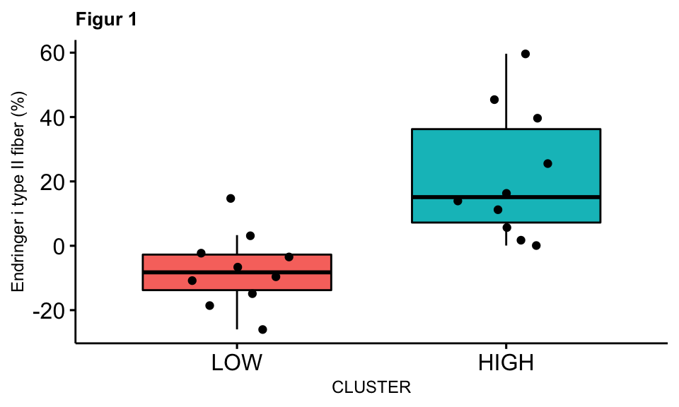

### Metode

For å kunne svare på spørsmålet om det var en signifikant forskjell mellom de to gruppene må jeg gjennomføre en t-test. Før jeg gjennomfører t-testen ser jeg på om verdiene i gruppene er normalfordelt og om det er like stor varians i gruppene.

#### Normalfordeling

For å teste om dataene fra de to gruppene er tilnærmet normalfordelt brukes en Shapiro-Wilk-test. Hvis resultatet av testen gir en p-verdi høyere enn 0.05 er dataene tilnærmet normalfordelt. Resultatet av testen ga en p-verdi på 0.2711333 i HIGH-responder gruppa og en p-verdi på 0.9904936 i LOW-responder gruppa. Figur 2 viser ved et QQ-plot at begge gruppene var tilnærmet normalfordelt.

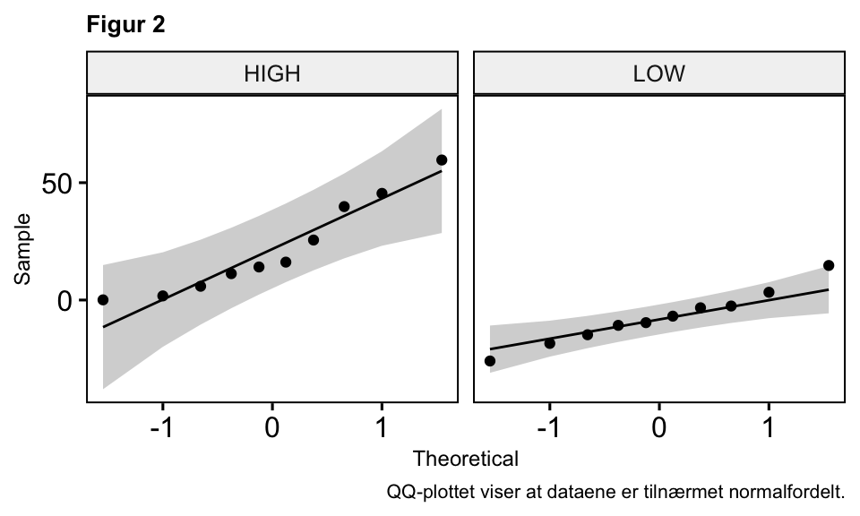

#### Varians

Deretter testet jeg variansen i mellom de to gruppene ved hjelp av en levene_test. Hvis p-verdien er mindre enn 0.05 er ikke variansen i gruppene lik. Er p-verdien over 0.05 er variansen i gruppene tilnærmet lik. Resultatet av testen ble en p-verdi på 0.1859132 og sier at variansen i de to gruppene er tilnærmet lik.

#### T-test

Resultatet av varians-testen viste at variansen i gruppene var tilnærmet lik. Dette betyr at når t-testen gjennomføres må det registreres at variansen er lik. Når det er to forskjellige grupper som skal testes opp mot hverandre må vi bruke en uavhengig t-test. Tabell 3 oppsummerer resultatet av testen.

| Tabell 3 Gruppe 1 | Tabell 3 Gruppe 2 | Tabell 3 Antall i gruppe 1 | Tabell 3 Antall i gruppe 2 | Tabell 3 P-verdi |
| --- | --- | --- | --- | --- |
| HIGH | LOW | 10 | 10 | 0.000827 |

#### Effect size

T-testen viste en signifikant P-verdi, men for å gjøre konklusjonen tydeligere er det greit å ta med effect size som et mål på hvor markant forskjellen faktisk er. Til å regne ut effect size bruker jeg Cohens D-formel. Cohens D-formel ga et resultat på 1.791958. Dette betegnes som en markant effekstørrelsen.

### Konklusjon

Gjennomsnittsendringen i type II muskelfibre var 21.964% (SD 20.169) i HIGH-responder gruppa og -7.436% (SD 11.470) i LOW-responder gruppa. Resultatet av en uavhengig t-test viste at det var en statistisk signifikant forskjell i mellom gruppene (P = 0.000827). Effect size regnet ut ved Cohens D-formel viste 1.79 og betegnes som markant.

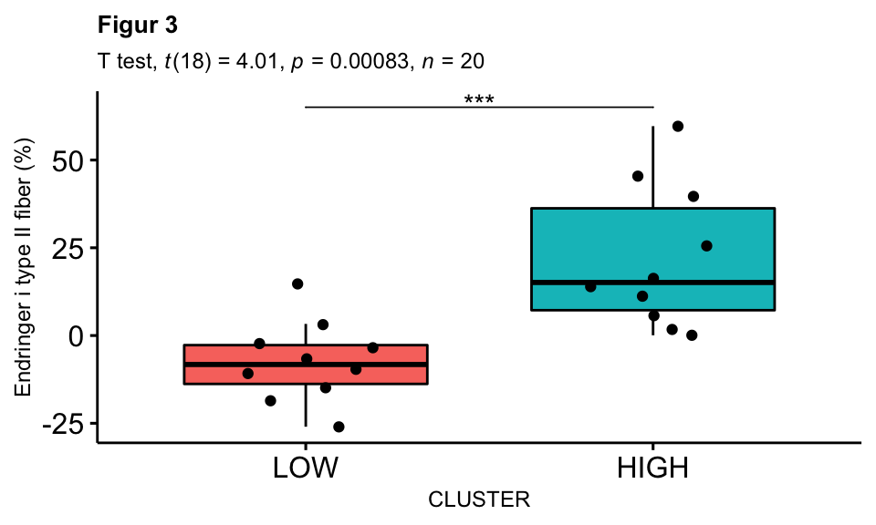